# SCEM Assignment 2

Max Kirwan

06/10/2021

## 1. Visualisation

```r
library(tidyverse)
library(Stat2Data)
data("Hawks")
hawksSmall<-drop_na(select(Hawks,Age,Day,Month,Year,CaptureTime,Species,Wing,Weight,Tail))
```

#### 1.1 Types of Variables

```r
dim(hawksSmall)
```

```
## [1] 897   9
```

```r
head(hawksSmall)
```

```
##   Age Day Month Year CaptureTime Species Wing Weight Tail
## 1   I  19     9 1992       13:30      RT  385    920  219
## 2   I  22     9 1992       10:30      RT  376    930  221
## 3   I  23     9 1992       12:45      RT  381    990  235
## 4   I  23     9 1992       10:50      CH  265    470  220
## 5   I  27     9 1992       11:15      SS  205    170  157
## 6   I  28     9 1992       11:25      RT  412   1090  230
```

1. Month - Discrete
2. Species - Categorical
3. Age - Categorical
4. Wing - Continuous
5. Weight - Continuous

#### 1.2 What’s wrong with this plot?

- No axis labels.
- No title.
- Too many visual cues… position, size and colour.

#### 1.3 Generate a histogram

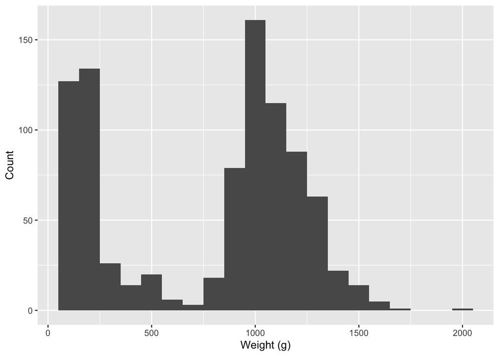

```r
ggplot(hawksSmall, aes(x=Weight)) + geom_histogram(binwidth=100) + xlab("Weight (g)") + ylab("Count")
```

The weights have a bimodal distribution with 2 distinct means, probably due to the distinct species of Hawk.

#### 1.4 Generate a density plot

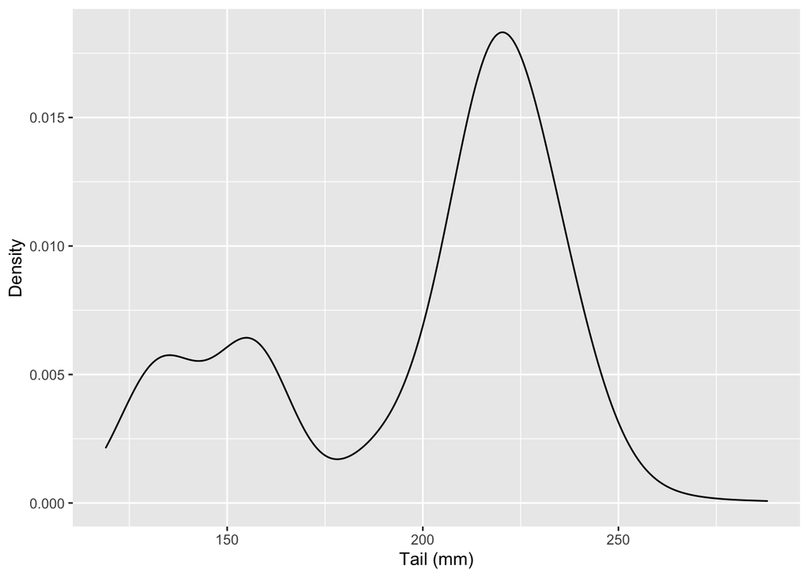

```r
ggplot(hawksSmall, aes(x=Tail)) + geom_density() + xlab("Tail (mm)") + ylab("Density")
```

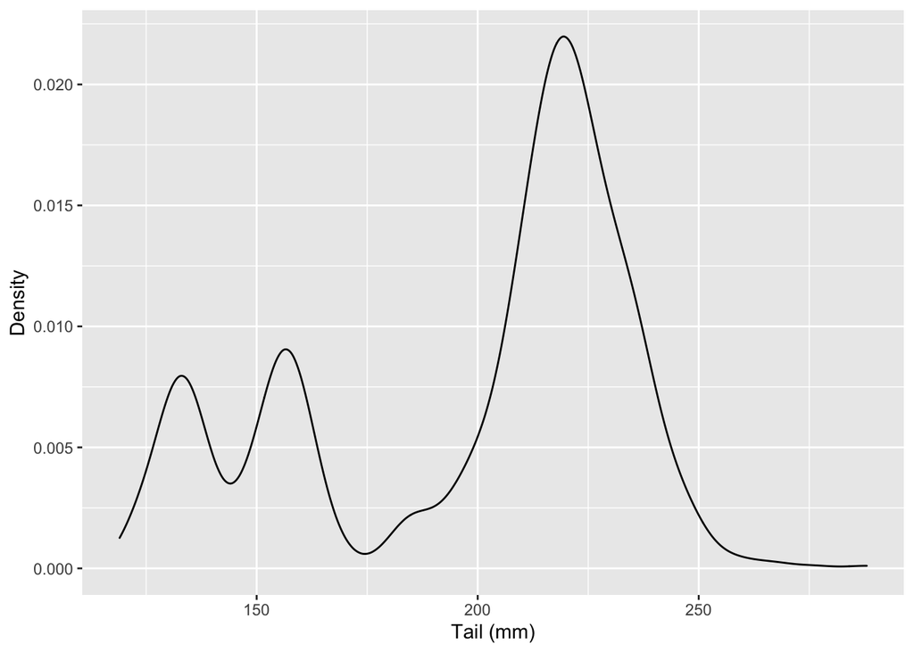

```r
ggplot(hawksSmall, aes(x=Tail)) + geom_density(adjust=0.5) + xlab("Tail (mm)") + ylab("Density")
```

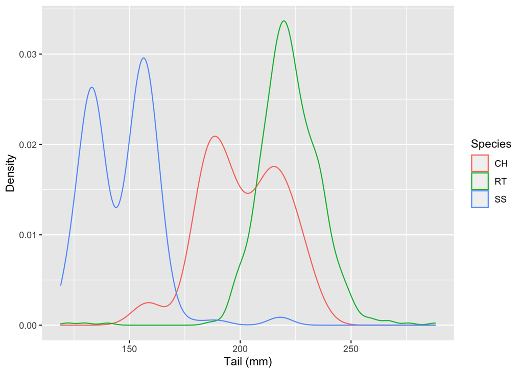

```r
ggplot(hawksSmall, aes(x=Tail, colour=Species)) + geom_density() + xlab("Tail (mm)") + ylab("Density")
```

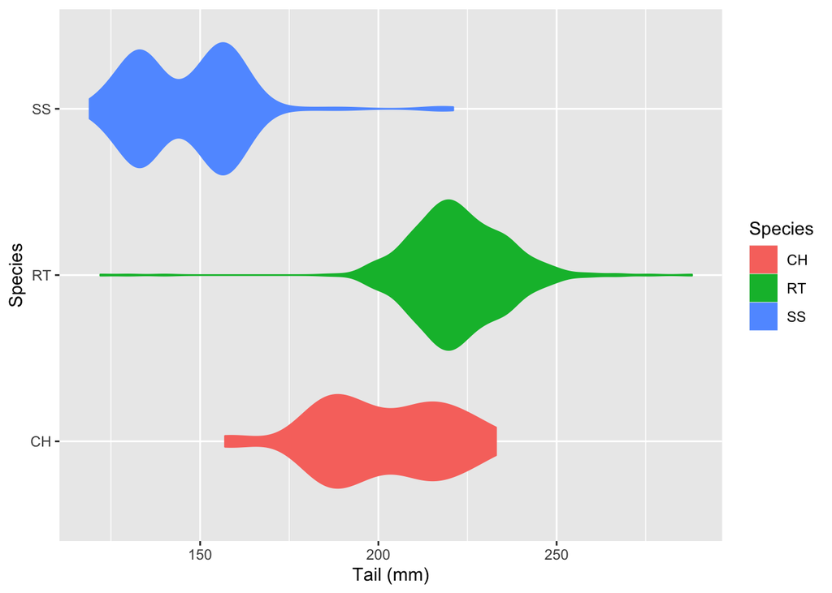

```r
ggplot(hawksSmall, aes(x=Tail, y=Species, colour=Species, fill=Species)) + geom_violin() + xlab("Tail (mm)") + ylab("Species")
```

#### 1.5 Scatter plots

There are 4 aesthetics present:

- Position to Tail
- Position to Weight
- Colour to Species
- Shape to Species

There are 3 glyphs present:

- Red circles
- Green triangles
- Blue squares

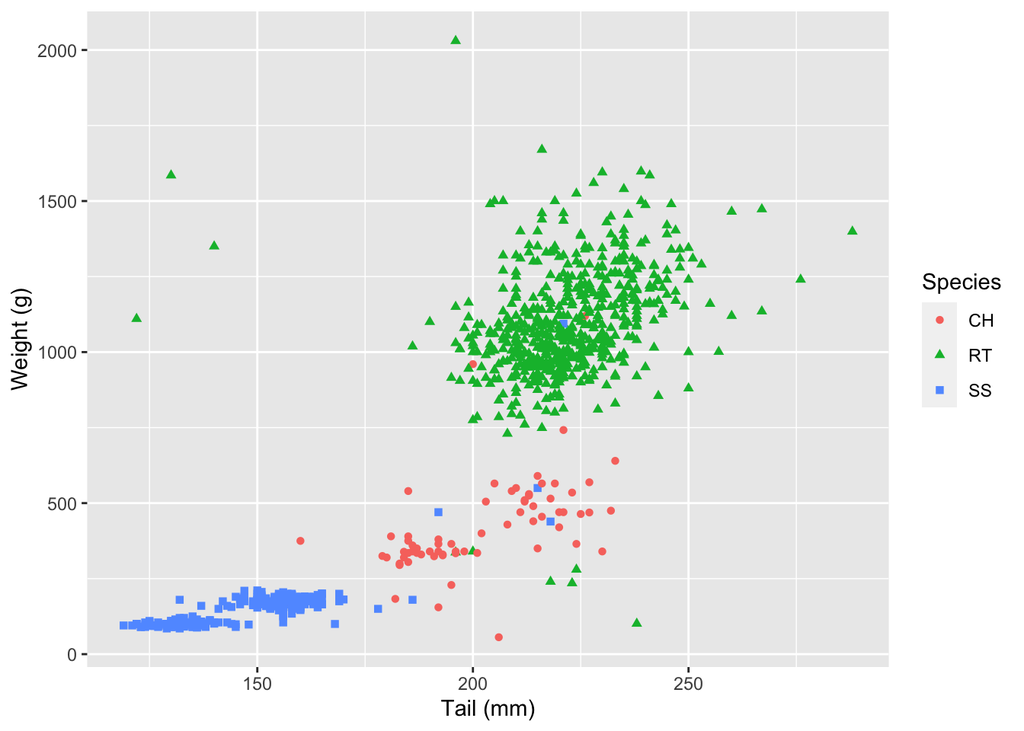

```r
ggplot(hawksSmall, aes(x=Tail, y=Weight, colour=Species, shape=Species)) + geom_point() + xlab("Tail (mm)") + ylab("Weight (g)")
```

#### 1.6 Trend lines and facet wraps

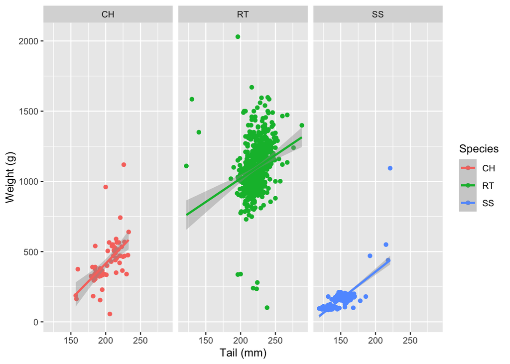

```r
ggplot(hawksSmall, aes(x=Tail, y=Weight, colour=Species)) + geom_point() + geom_smooth(method="lm") + facet_wrap(vars(Species)) + xlab("Tail (mm)") + ylab("Weight (g)")
```

The visual cues used in this plot are position, colour, angle and direction. In all 3 species of hawk there is a positive correlation between weight and tail length.

## 2. Data Wrangling

#### 2.1 Select and filter functions

```r
hSF <- Hawks %>%
  filter(Species=="RT", Weight>=1000) %>%
  select(Wing, Weight, Tail)
head(hSF)
```

```
##   Wing Weight Tail
## 1  412   1090  230
## 2  412   1210  210
## 3  405   1120  238
## 4  393   1010  222
## 5  371   1010  217
## 6  390   1120  213
```

The dataframe hSF has 3 variables; Wing, Weight and Tail and 398 examples/observations/cases.

#### 2.2 The arrange function

```r
head(arrange(hSF, Wing))
```

```
##    Wing Weight Tail
## 1  37.2   1180  210
## 2 111.0   1340  226
## 3 199.0   1290  222
## 4 241.0   1320  235
## 5 262.0   1020  200
## 6 277.0   1500  207
```

#### 2.2 Join and rename functions

```r
species_code <- c("CH","RT", "SS")
species_name_full <- c("Cooper's", "Red-tailed", "Sharp-shinned")
species_names <- data.frame(species_code, species_name_full)
species_names
```

```
##   species_code species_name_full
## 1           CH          Cooper's
## 2           RT        Red-tailed
## 3           SS     Sharp-shinned
```

```r
hawksFullName <- Hawks %>%
  left_join(species_names, by=c("Species"="species_code")) %>%
  select(-Species) %>%
  rename(Species = species_name_full)
head(select(hawksFullName, Species, Wing, Weight))
```

```
##         Species Wing Weight
## 1    Red-tailed  385    920
## 2    Red-tailed  376    930
## 3    Red-tailed  381    990
## 4      Cooper's  265    470
## 5 Sharp-shinned  205    170
## 6    Red-tailed  412   1090
```

#### 2.4 The mutate function

```r
hawksWithBMI <- Hawks %>%
  mutate(bird_BMI = 1000*Weight/Wing^2) %>%
  filter(bird_BMI<=100) %>%
  select(Species, bird_BMI) %>%
  arrange(desc(bird_BMI))
head(hawksWithBMI)
```

```
##   Species bird_BMI
## 1      RT 32.57493
## 2      RT 22.72688
## 3      CH 22.40818
## 4      RT 19.54932
## 5      CH 15.21998
## 6      RT 14.85927
```

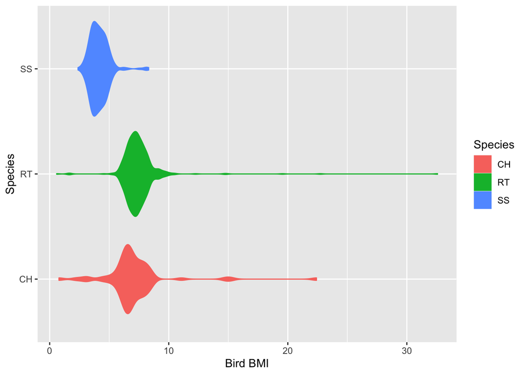

```r
ggplot(hawksWithBMI, aes(x=bird_BMI, y=Species, colour=Species, fill=Species)) + geom_violin() + xlab("Bird BMI") + ylab("Species")
```

#### 2.5 Summarise and group-by functions

```r
hawksFullName %>%
  group_by(Species) %>%
  summarise(num_rows=n(), mean_wing=mean(Wing,na.rm=1), median_wing=median(Wing,na.rm=1), trimmed_mean_wing=mean(Wing,na.rm=1,trim=0.1), mean_wing_tail_ratio=mean(Wing/Tail,na.rm=1))
```

```
## # A tibble: 3 × 6
##   Species       num_rows mean_wing median_wing trimmed_mean_wi… mean_wing_tail_…
##   <chr>            <int>     <dbl>       <dbl>            <dbl>            <dbl>
## 1 Cooper's            70      244.         240             243.             1.22
## 2 Red-tailed         577      383.         384             385.             1.73
## 3 Sharp-shinned      261      185.         191             184.             1.26
```

```r
hawksFullName %>%
  group_by(Species) %>%
  select(Wing, Weight, Culmen, Hallux, Tail, StandardTail, Tarsus, Crop) %>%
  summarise(across(everything(),~sum(is.na(.x))))
```

```
## # A tibble: 3 × 9
##   Species        Wing Weight Culmen Hallux  Tail StandardTail Tarsus  Crop
##   <chr>         <int>  <int>  <int>  <int> <int>        <int>  <int> <int>
## 1 Cooper's          1      0      0      0     0           19     62    21
## 2 Red-tailed        0      5      4      3     0          250    538   254
## 3 Sharp-shinned     0      5      3      3     0           68    233    68
```

## 3. Exploratory Data Analysis

#### 3.1 Combining location estimators with the summarise function

```r
hawksFullName %>%
  group_by(Species) %>%
  summarise(Wing_mean=mean(Wing,na.rm=1), Wing_t_mean=mean(Wing,na.rm=1,trim=0.1), Wing_med=median(Wing,na.rm=1), Weight_mean=mean(Weight,na.rm=1), Weight_t_mean=mean(Weight,na.rm=1,trim=0.1), Weight_med=median(Weight,na.rm=1))
```

```
## # A tibble: 3 × 7
##   Species       Wing_mean Wing_t_mean Wing_med Weight_mean Weight_t_mean Weight_med
##   <chr>             <dbl>       <dbl>    <dbl>       <dbl>         <dbl>      <dbl>
## 1 Cooper's           244.        243.      240        420.          410.       378.
## 2 Red-tailed         383.        385.      384       1094.         1089.      1070
## 3 Sharp-shinned      185.        184.      191        148.          140.       155
```

#### 3.2 Location and dispersion estimators under linear transformations

$X_1,...,X_n$ has sample mean $\mu$.

Let $\tilde{X_i} = a \cdot X_i + b$ for $a,b\in \mathbb{R}$.

$X_1,...,X_n$ has sample variance $S^2_X = \frac{\Sigma(X_i - \mu)^2}{n-1}$.

Then $\tilde{X_i}$ has sample variance
$$\frac{\Sigma(\tilde{X_i} - \tilde{\mu})^2}{n-1} = \frac{\Sigma(a \cdot X_i + b - a \cdot \mu - b)^2}{n-1} = \frac{a^2\Sigma(X_i - \mu)^2}{n-1} = a^2 \cdot S^2_X.$$

Also, $\tilde{X_i}$ has sample standard deviation $a \cdot S_X$ where $S_X$ is the sample standard deviation of $X_i$.

#### 3.3 Robustness of location estimators

```r
hal<-Hawks$Hallux # Extract the vector of hallux lengths
hal<-hal[!is.na(hal)] # Remove any nans
outlier_val<-100
num_outliers<-10
corrupted_hal<-c(hal,rep(outlier_val,times=num_outliers))
mean(hal)
```

```
## [1] 26.41086
```

```r
mean(corrupted_hal)
```

```
## [1] 27.21776
```

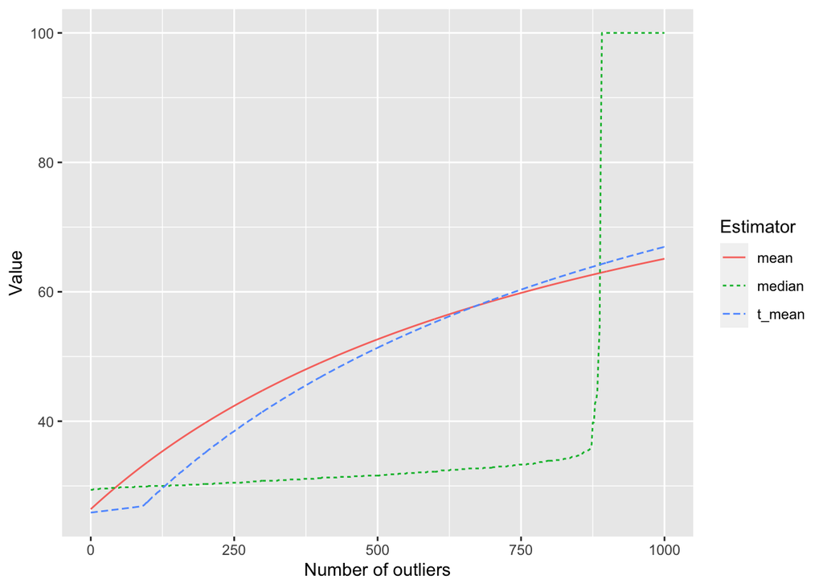

```r
num_outliers_vect<-seq(0,1000)
means_vect<-c()
for(num_outliers in num_outliers_vect){
  corrupted_hal<-c(hal,rep(outlier_val,times=num_outliers))
  means_vect<-c(means_vect,mean(corrupted_hal))
}

medians_vect<-c()
for(num_outliers in num_outliers_vect){
  corrupted_hal<-c(hal,rep(outlier_val,times=num_outliers))
  medians_vect<-c(medians_vect,median(corrupted_hal))
}

t_means_vect<-c()
for(num_outliers in num_outliers_vect){
  corrupted_hal<-c(hal,rep(outlier_val,times=num_outliers))
  t_means_vect<-c(t_means_vect,mean(corrupted_hal,trim=0.1))
}

df_means_medians<-data.frame(num_outliers=num_outliers_vect, mean=means_vect,t_mean=t_means_vect,
median=medians_vect)

df_means_medians%>%
  pivot_longer(!num_outliers, names_to = "Estimator", values_to = "Value")%>%
  ggplot(aes(x=num_outliers,color=Estimator,linetype=Estimator,y=Value))+ geom_line()+xlab("Number of outliers")
```

#### 3.4 Box plots and outliers

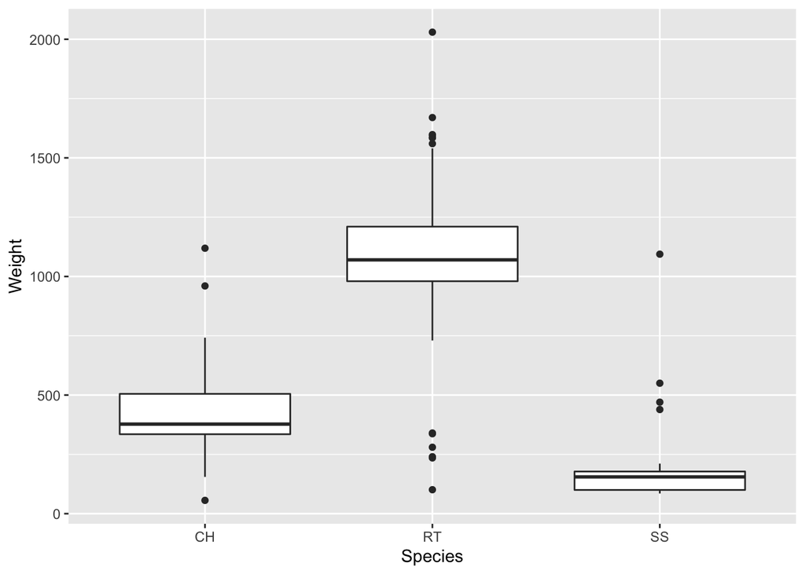

```r
ggplot(Hawks, aes(x=Species,y=Weight)) + geom_boxplot()
```

```r
# Creating a function which computes the number of outliers within a sample
outliers <- function(x){
  q25 <- quantile(x,0.25,na.rm=1)
  q75 <- quantile(x,0.75,na.rm=1)
  IQR <- q75 - q25
  return(x[((x<q25-1.5*IQR)|(x>q75+1.5*IQR))&!is.na(x)])
}
num_outliers <- function(x){return(length(outliers(x)))}

Hawks %>%
  group_by(Species) %>%
  summarise(num_outliers_weight=num_outliers(Weight))
```

```
## # A tibble: 3 × 2
##   Species num_outliers_weight
##   <fct>                 <int>
## 1 CH                        3
## 2 RT                       13
## 3 SS                        4
```